# Understanding a Simulated Tax Rate

Project Lecture

## Overview

- Research question: what is the causal affect of an increase in taxes on:
  - charitable giving
  - labour supply
  - wealth
- Using data from the Consumer Expenditure survey (for US)
  - years: 2016-2019 $\Rightarrow$ **pooled cross section**.
  - avoided 2020 due to Covid

## Specification

Linear regression model

$$y_{it} = \alpha + \beta tax_{it} + \mathbf{x}_{it}\gamma + u_{it}$$

where,

$$tax_{it} = T(\mathbf{x}_{it},s,t)$$

**Problem:**

- $tax_{it}$ is endogeneous
  - determined by factors that are “self-selected”: $\mathbf{x}_{it}$, potentially $s$
- BUT $tax_{it}$ is also determined by exogenous tax policy: $T(\cdot,s,t)$

## Simulated instrument

The literature on elasticity of taxable income (Gruber and Saez 2002) asks a similar question:<sup>1</sup>

$$y_{it} = \alpha + \tau tax_{it} + \mathbf{x}_{it}\eta + u_{it}$$

Where $y_{it}$ is reported taxable income and $tax_{it}$ is the net-of-tax rate (i.e. 1 minus tax rate)

- Important policy parameter for understanding how tax changes translate into changes in taxable income (i.e. Laffer curve)
[^1]: The paper is available online: [www.sciencedirect.com](https://www.sciencedirect.com/science/article/pii/S0047272701000858)

## Identification

Since $tax_{it}$ is endogenous

- Instrument:

$$sim_{it} = TAXSIM(\mathbf{x}_{it},s,t)$$

- Predicted $tax_{it}$ based on observable income *in the previous period*
- Paper use panel data from administrative tax records

**Warning**

This project takes inspiration from Gruber and Saez (2002), but we do not have the same data structure. The authors use panel data to look at changes in taxes at the individual/household level. There are other useful examples of approaches to simulated instruments, like Grossman, Tello-Trillo, and Willage (2022) from Tutorial 4.

## Reduced form

For this exercise, you will not observe $tax$.

- Can’t conduct IV estimation
- But, you can estimate the reduced form relationship

$$y_{it} = \delta + \beta sim_{it} + x_{it}\gamma + v_{it}$$

## Identifying variation

Suppose you regress $y$ on $sim$ alone

$$\beta^s = \frac{Cov(y_{it},sim_{it})}{Var(sim_{it})}$$

What is the source of variation in $sim_{it}$?

1. Endogenous factors
2. Exogenous factors

If instead, you regress $y$ on $sim$ and a set of controls $\mathbf{x}$

$$y_{it} = \delta + \beta sim_{it} + \mathbf{x}_{it}\gamma + v_{it}$$

Then,

$$\beta = \frac{Cov(\tilde y_{it},\widetilde{sim}_{it})}{Var(\widetilde{sim}_{it})}$$

where $\widetilde{sim}_{it}$ is residual from regressing $sim$ on $\mathbf{x}$

## Controls

So, the controls you choose are important!

- To “isolate” the exogenous variation in $sim$ you need to control for the right factors.

**Income**

The primary determinant of taxes is income. In Gruber and Saez (2002) the authors use panel data to control for income in the previous period. Meaning income cannot be an outcome of the contemporaneous tax change.

In the paper, the simulated taxes for the current period are based on current tax policy, but previous period’s income.

## Matching

If you think about it from a matching perspective, the instrument plugs a set of characteristics into a TAXSIM function<sup>1</sup>

$$sim_{it} = TAXSIM(\mathbf{x}_{it},s,t)$$

That takes as inputs:

- The household’s characteristics
- Their state
- The year
[^2]: This is the name of the tax simulated used to construct the variable in the CEX.

If two households ($i,i'$) have the same $\mathbf{x}$, live in the same $s$ state, in the same period $t$,

$$TAXSIM(\mathbf{x}_{it},s,t) = TAXSIM(\mathbf{x}_{i't},s,t)$$

**Perfect match!**

If you hold $\mathbf{x}$ fixed (e.g. control for $\mathbf{x}$),

- with a single state and time period,
- there is no (identifying) variation in $sim$.

## Different jurisdictions

But you could find two households ($i,i'$) with the same $\mathbf{x}$ in the same period $t$ who live in different states ($s,s'$):

$$TAXSIM(\mathbf{x}_{it},s,t) \neq TAXSIM(\mathbf{x}_{i't},s',t)$$

**IF** the states have different tax policies.

- You now have variation in $sim$ based on the state people live in.
- With a single cross-section of data this would be the best you can do.
- A concern might be that *people choose where to live*.
  - unobserved preferences that determine the outcome (giving, labour, wealth) may also determine decisions on where to live.
  - e.g., people know that Florida has low taxes and is a nice place to retire

## Repeated observations

With repeated observations, you can do a bit better.

- You could find two households ($i,i'$) with the same $\mathbf{x}$, **in the same state** $s$, but different periods ($t,t'$)

$$TAXSIM(\mathbf{x}_{it},s,t) \neq TAXSIM(\mathbf{x}_{i't'},s,t')$$
**IF** there is a *policy change*.

- Ideally, you would like different states to enact different policy changes
- At a minimum, you want the policy change to affect different groups of people differently.

## Policy change

The reason you were provided with a pooled cross-section of data from 2016-2019 is the Tax Cuts and Jobs Act (effective 1 January 2018)

[figure not shown]

## Simulation (1)

Simulation for single, 40-year-old, with USD 60,000 income

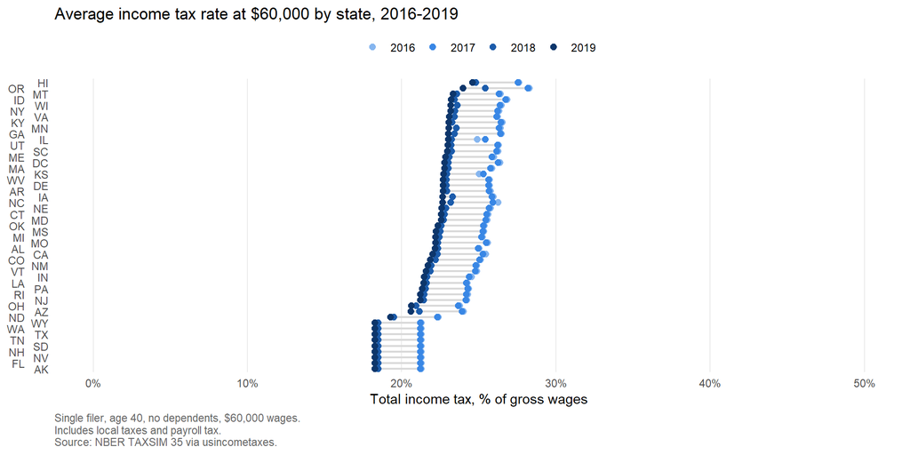

## Simulation (1)

Simulation for single, 40-year-old, with USD 120,000 income

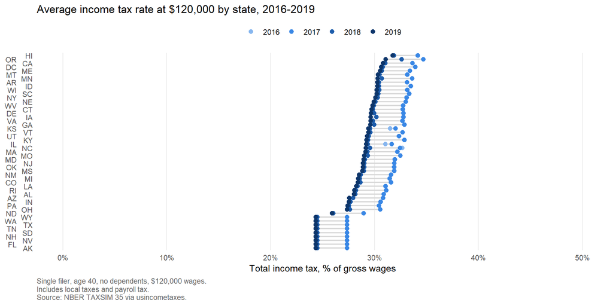

## Simulation (3)

Simulation for married, 40-year-old couple, single-earner, 2 children (ages 6 and 8), with USD 60,000 income

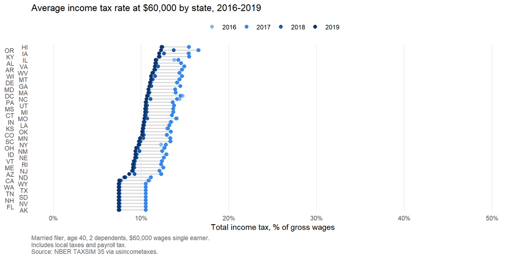

## Simulation (4)

Simulation for married, 40-year-old couple, double-earner, 2 children (ages 6 and 8), with USD 60,000 income **each**

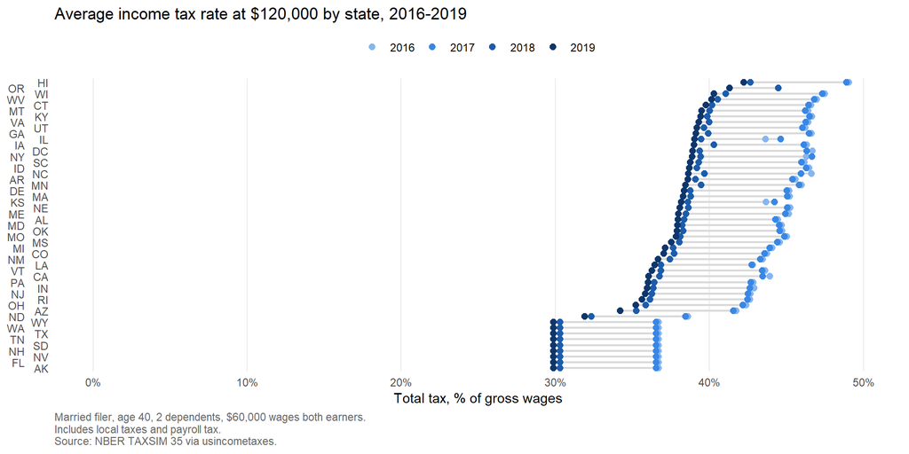

## CEX (2016-2019)

The data at your disposal is a repeated cross section of **households**.

- In the CEX, households are surveyed four times (i.e. a panel), but only the final interview asks about wealth. This is the one you observe.
- Income is also recorded in the final interview.
  - it represents the previous 12 months’ income (i.e. partly lagged, by up to 12 months)
  - may not span an exact calendar/tax year.
- The tax variables are a weighted average of taxes for overlapping tax years,
  - based on the months reported in each tax year
  - **not ideal**, but does include some exogenous variation resulting from policy reforms
  - you really see tax change taking effect in 2019 data, as 2018 income records partly reflect 2017 income.

## CEX Plots

```stata
use "$data_dir\cex2016_2019.dta", clear

drop if state_fips==.
drop if inlist(state_fips,54,33,18,19,10,11)
drop if atr_total<0 | atr_total>1

collapse (mean) atr_total, by(region release_year)

xtset region release_year
```

```stata
xtline atr_total, overlay xtitle(Survey Year) ytitle(Average of atr_total) ylabel(0.05(0.05)0.15) legend(pos(2) ring(0)) title("Selecting on households within incomes 30,000-120,000 USD")
```

[figure not shown]

## Bibliography

Grossman, Daniel S, Sebastian Tello-Trillo, and Barton Willage. 2022. “Health Insurance for Whom? The ‘Spill-up’effects of Children’s Health Insurance on Mothers.” National Bureau of Economic Research.

Gruber, Jon, and Emmanuel Saez. 2002. “The Elasticity of Taxable Income: Evidence and Implications.” *Journal of Public Economics* 84 (1): 1–32.